# Analyzing RNA-binding protein profiles from eCLIP dat

## Data Analysis

### Heat Map Analysis

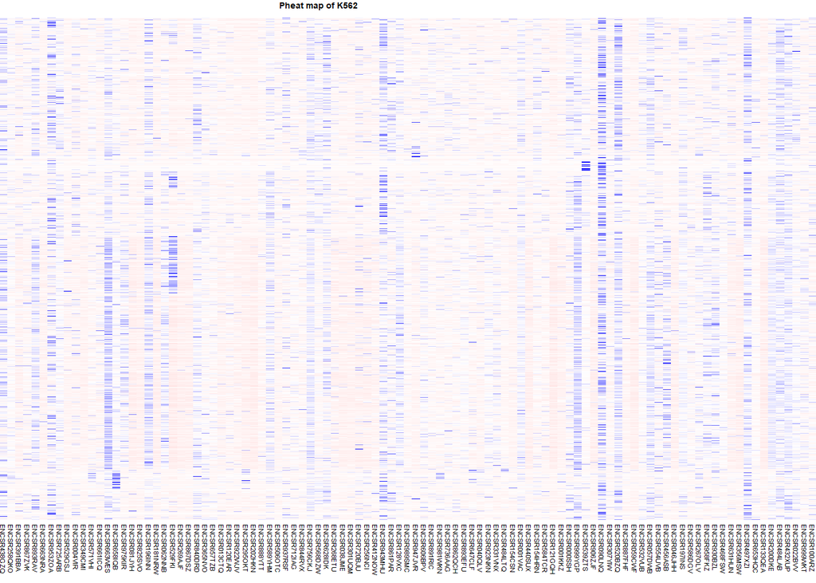

Looking at the pheatmap, we see many events/genes that show little to no expression and many different types of genes. This will be later filtered out.

### Clustering Analysis - K562 cells

For the clustering analysis, we use a filtered SummarizedExperiment. It contains data for mRNAs and lncRNAs that bind to at least one protein in the eCLIP experiments. We narrow our focus to these two types of RNAs. The reasons are that they are very well represented in the dataset, and that unlike mRNAs, the functions of almost all lncRNAs remain a mystery. If we see that similar mRNAs are bound by similar proteins, then perhaps this might also hold true for lncRNAs.

The first step is to load the SummarizedExperiment. In “assay(se)”, the rows are the ENSEMBL gene ID’s and the columns are experiment ID’s (note that each eCLIP experiment is performed with a single, unique protein).

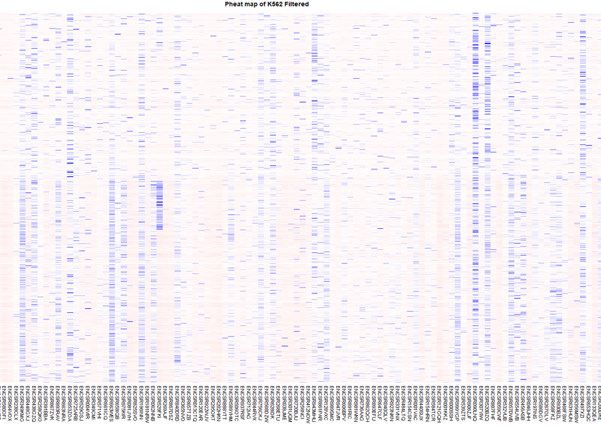

```r
se2_pheatmap <- as.data.frame(assay(K562.se2))
gene_type <- as.data.frame(K562.se2@elementMetadata@listData$Gene_type)
se2_pheatmap <- cbind(se2_pheatmap,gene_type)
#annotating each event by the gene type
Anno <- data.frame(GeneType = se2_pheatmap$`K562.se2@elementMetadata@listData$Gene_type`)
rownames(se2_pheatmap) <- row.names(se2_pheatmap)
rownames(Anno) <- row.names(se2_pheatmap)
se2_pheatmap <- se2_pheatmap[order(se2_pheatmap$`K562.se2@elementMetadata@listData$Gene_type`),]
pheatmap(se2_pheatmap[1:135], cluster_rows=F, show_rownames=F,
         cluster_cols=F, main = "Pheat map of K562 Filtered", border_color = T,annotation_row = Anno,
         color =colorRampPalette(c('red','white','blue'))(100), scale = "row",fontsize = 4, cellwidth =5)
```

Judging by the counts data, some proteins heavily bind our RNAs, and others bind more lightly. Unsurprisingly (in hindsight), working with the unscaled data produces poor clustering results because of this wide spread. As such, we scale the counts data by column sums, effectively normalizing the protein counts. In addition, we also remove any RNAs relatively unbound by proteins (RNAs with row sums less than 100).

```r
### scale assay(se) by column sums, multiply by 10e7 and round so that the values we work with are integers
prot.sum   <- colSums(assay(K562.se2))
assay(K562.se2) <- scale(assay(K562.se2), center=FALSE, scale=prot.sum) * 10e7 %>%
              round(digits = 0)
### remove RNAs with low eCLIP data
rna.sum  <- rowSums(assay(K562.se2))
genes    <- rownames(assay(K562.se2))
genes.hi <- genes[which(rna.sum>100)]
### recreate SummarizedExperiment
se <- SummarizedExperiment(assays=list(counts=assay(K562.se2)[genes.hi,]^0.25), colData = colData(K562.se2), rowData=rowData(K562.se2)[genes.hi,])
```

One preliminary question is: how similar are the 135 eCLIP proteins in terms of their binding to mRNAs and lncRNAs?

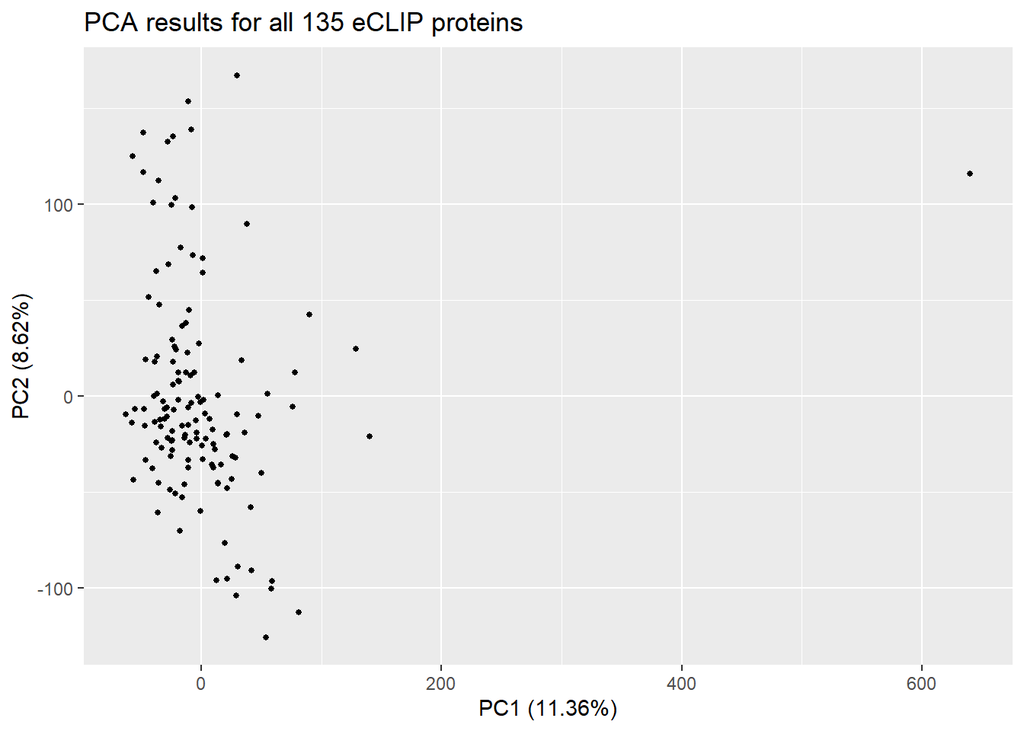

```r
### PCA on eCLIP proteins
prot.pca <- prcomp(t(assay(se)))
prot.pca.var <- prot.pca$sdev^2
prot.pca.var.prop <- prot.pca.var/sum(prot.pca.var) * 100
prot.PC1PC2 <- data.frame(prot.pca$x[,1:2])
prot.PC1PC2[rownames(colData(se)),"proteins"] <- colData(se)$Experiment.target
ggplot(prot.PC1PC2) + geom_point(aes(PC1, PC2), size = 1) +
  ggtitle('PCA results for all 135 eCLIP proteins') +
  xlab('PC1 (11.36%)') +
  ylab('PC2 (8.62%)')
```

From the plot above, we see that YBX3 is way out in the distance. Perhaps this is why PC1 and PC2 explain such a small percent of the variance. What happens to the PCA results when we remove YBX3?

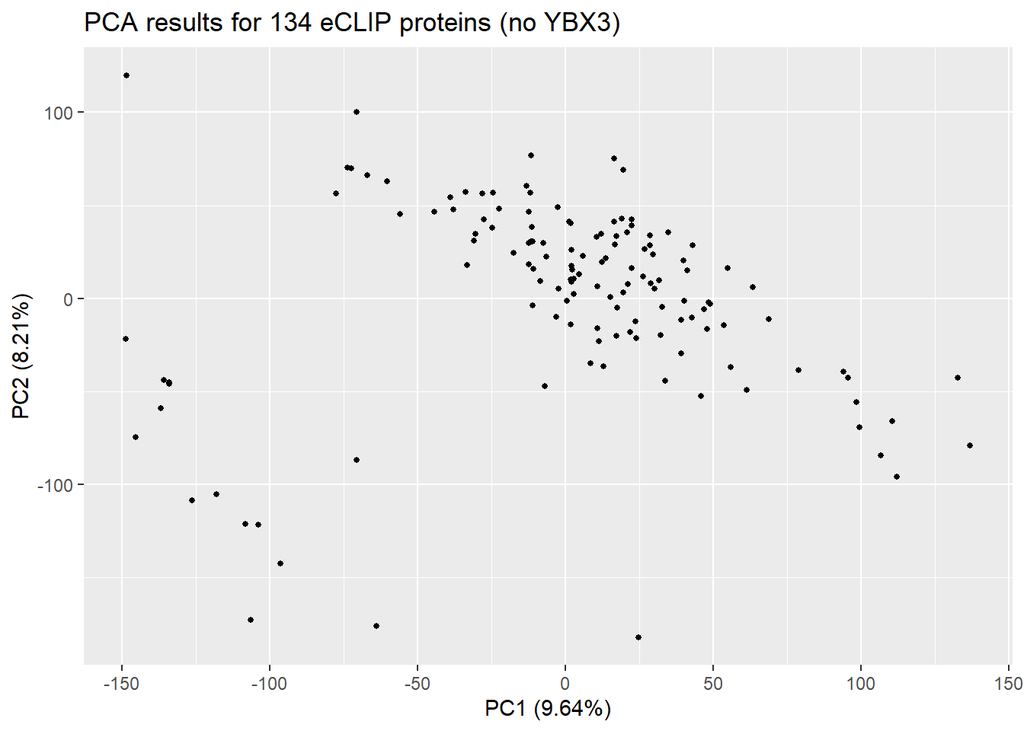

```r
### what happens when we remove YBX3?
idx <- which(prot.PC1PC2$PC1 == max(prot.PC1PC2$PC1))
name <- rownames(prot.PC1PC2[50,])
no.ybx3 <- subset(assay(se), select=-c(ENCSR529FKI))
prot.pca <- prcomp(t(no.ybx3))
prot.pca.var <- prot.pca$sdev^2
prot.pca.var.prop <- prot.pca.var/sum(prot.pca.var) * 100
prot.PC1PC2 <- data.frame(prot.pca$x[,1:2])
ggplot(prot.PC1PC2) + geom_point(aes(PC1, PC2), size = 1) +
  ggtitle('PCA results for 134 eCLIP proteins (no YBX3)') +
  xlab('PC1 (9.64%)') +
  ylab('PC2 (8.21%)')
```

Now PC1 and PC2 explain even less of the variance! We can conclude that the eCLIP proteins are all very different in their scaled binding of RNAs. It is however intriguing that we see two clusters on the above plot. Perhaps one cluster of proteins more frequently binds lncRNAs? We delve into this more by determining which proteins are in the bottom cluster and which are in the top cluster, and then per cluster, computing the average eCLIP counts per lncRNA and per mRNA.

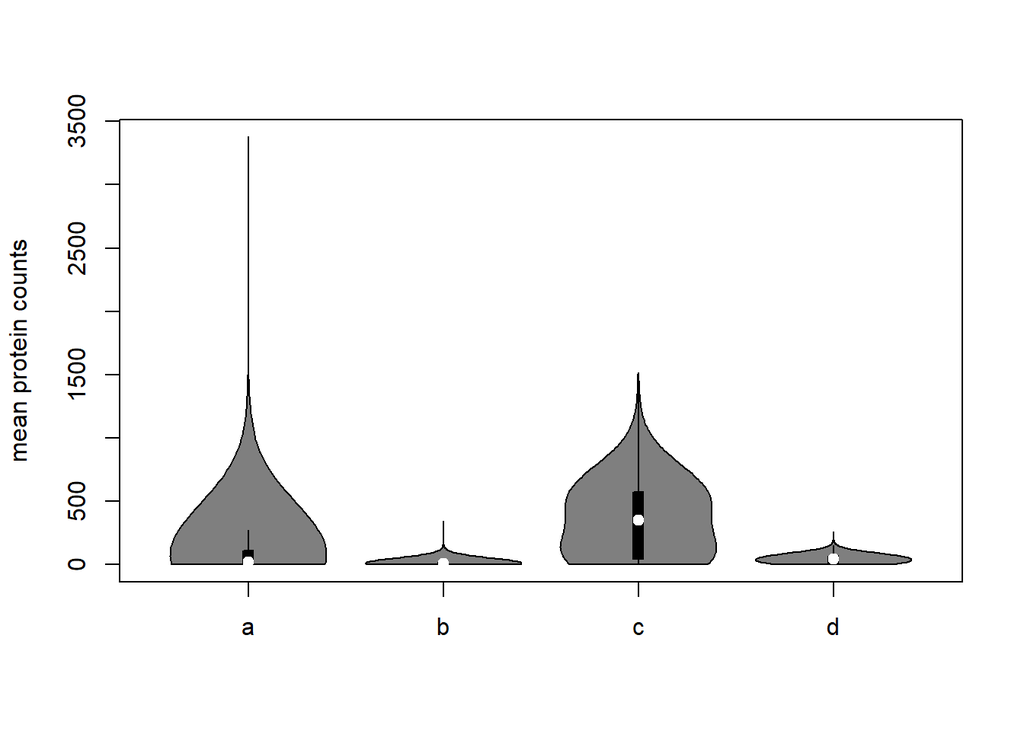

```r
bot.cluster <- prot.PC1PC2[prot.PC1PC2$PC1 < -50 & prot.PC1PC2$PC2 < 0,]
top.cluster <- prot.PC1PC2[prot.PC1PC2$PC1 > -50 | prot.PC1PC2$PC2 > 0,]
lncRNA.id <- rowData(se)$Gene_type=='lncRNA'
prtcod.id <- rowData(se)$Gene_type=='protein_coding'
genes   <- rownames(rowData(se))
lncRNAs <- genes[lncRNA.id]
prtcods <- genes[prtcod.id]
### does one cluster seem to primarily bind lncRNAs while the other mRNAs?
lnc.top <- rowSums( assay(se)[lncRNAs,rownames(top.cluster)] ) / length(top.cluster)
lnc.bot <- rowSums( assay(se)[lncRNAs,rownames(bot.cluster)] ) / length(bot.cluster)
prt.top <- rowSums( assay(se)[prtcods,rownames(top.cluster)] ) / length(top.cluster)
prt.bot <- rowSums( assay(se)[prtcods,rownames(bot.cluster)] ) / length(bot.cluster)
### a = lncRNAs bound by proteins from    top cluster
### b = lncRNAs bound by proteins from bottom cluster
### c =   mRNAs bound by proteins from    top cluster
### d =   mRNAs bound by proteins from bottom cluster
vioplot(lnc.top, lnc.bot, prt.top, prt.bot,
        names=c('a','b','c','d'))
title(ylab="mean protein counts")
```

Before we continue, let’s color-code lncRNAs (teal) and mRNAs (coral) in the SummarizedExperiment. Let’s also define a density function. This will all be helpful later.

```r
### color-code lncRNAs and mRNAs in the se
rowData(se)[lncRNA.id, "colors"] <- "#f34c28"
rowData(se)[prtcod.id, "colors"] <- "#2ca1d7"
### define density function
theme_set(theme_bw(base_size = 16))
get_density <- function(x, y, ...) {
  dens <- MASS::kde2d(x, y, ...)
  ix <- findInterval(x, dens$x)
  iy <- findInterval(y, dens$y)
  ii <- cbind(ix, iy)
  return(dens$z[ii])
}
```

The main subject we would like to explore is clustering of lncRNAs and mRNAs based on the proteins they bind to. To do so, we run a PCA on the scaled counts data in the “assay(se)”.

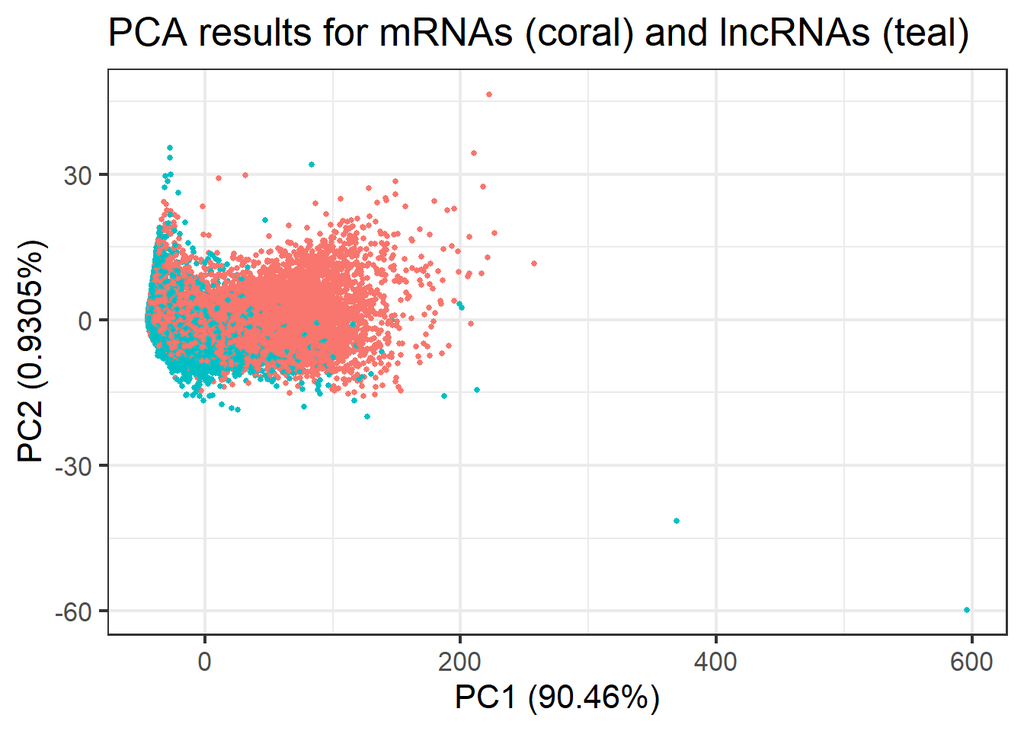

```r
### PCA on mRNAs and lncRNAs
se.pca <- prcomp(assay(se))
se.pca.var <- se.pca$sdev^2
se.pca.var.prop <- se.pca.var/sum(se.pca.var) * 100
se.PC1PC2 <- data.frame(se.pca$x[,1:2])
se.PC1PC2$colors <- rowData(se)$colors
ggplot(se.PC1PC2) +
  geom_point(aes(PC1, PC2, color = colors), size = 1) +
  theme(legend.position="none") +
  ggtitle('PCA results for mRNAs (coral) and lncRNAs (teal)') +
  xlab('PC1 (90.46%)') +
  ylab('PC2 (0.9305%)')
```

Based on the plot above, we seem to see a slight clustering of mRNAs vs. lncRNAs. It is difficult to draw conclusions from this plot because there is no way of knowing the density of the datapoints. Below, we will visualize results for lncRNAs and mRNAs separately, accounting for density.

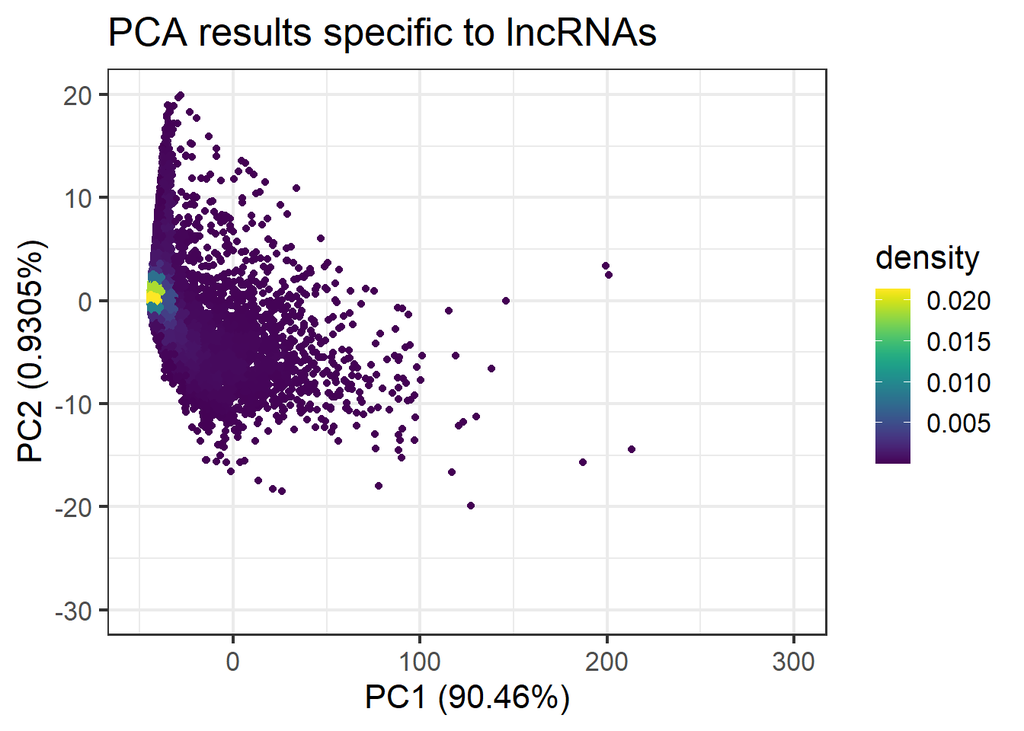

```r
### show results for lncRNAs only
se.lncRNA <- se.PC1PC2[lncRNAs,]
se.lncRNA$density <- get_density(se.lncRNA$PC1, se.lncRNA$PC2, n = 100)
ggplot(se.lncRNA) +
  geom_point(aes(PC1, PC2, color = density)) +
  scale_color_viridis() +
  xlim(-50, 300) +
  ylim(-30,  20) +
  ggtitle('PCA results specific to lncRNAs') +
  xlab('PC1 (90.46%)') +
  ylab('PC2 (0.9305%)')
```

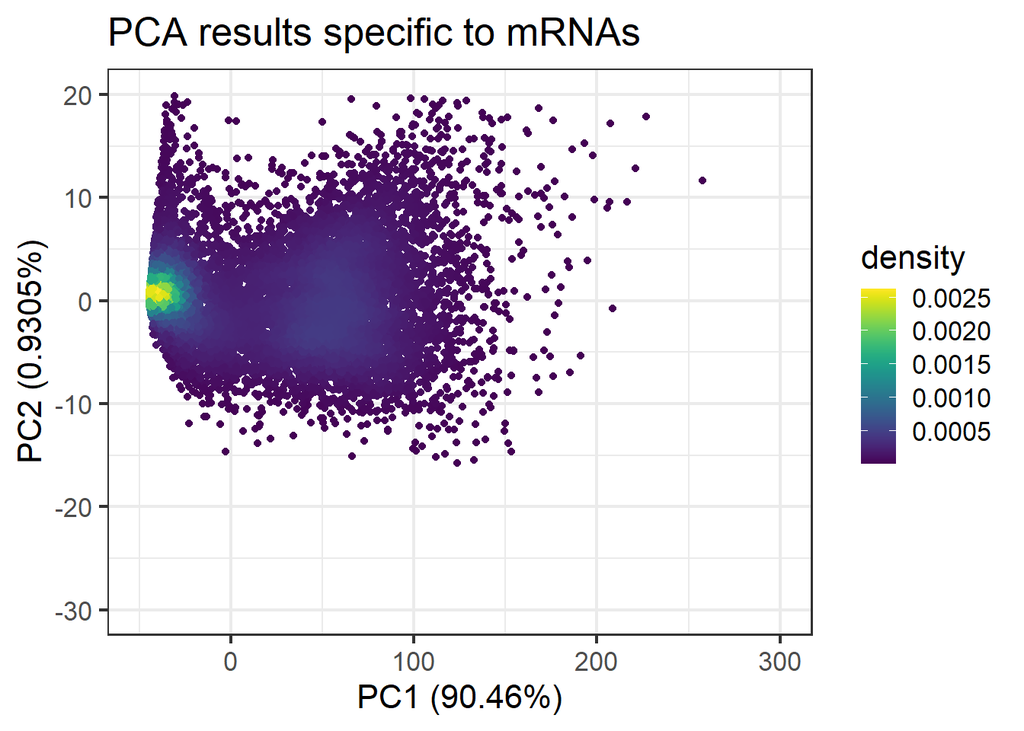

```r
### show results for mRNAs only
se.prtcod <- se.PC1PC2[prtcods,]
se.prtcod$density <- get_density(se.prtcod$PC1, se.prtcod$PC2, n = 100)
ggplot(se.prtcod) +
  geom_point(aes(PC1, PC2, color = density)) +
  scale_color_viridis() +
  xlim(-50, 300) +
  ylim(-30,  20) +
  ggtitle('PCA results specific to mRNAs') +
  xlab('PC1 (90.46%)') +
  ylab('PC2 (0.9305%)')
```

Interesting that we see two high density areas on the PCA plot for mRNAs. Let’s explore these areas further with some GO-term enrichment analyses. Note that we did try to repeat this analysis for lncRNAs, but not surprisingly, there aren’t enough GO terms assigned to lncRNAs to yield any results.

```r
hub <-AnnotationHub()
```

```
## snapshotDate(): 2022-04-25
```

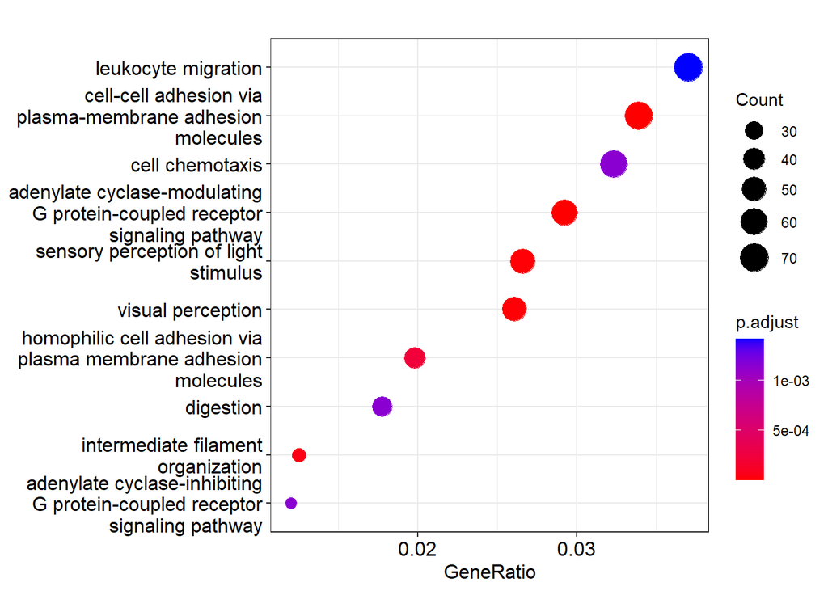

```r
### let's first look at the left-most high-density area
spot1 <- se.prtcod[which( se.prtcod$PC1 > -50 &
                          se.prtcod$PC1 < -25 &
                          se.prtcod$PC2 > -3 &
                          se.prtcod$PC2 <  3),]
gene1 <- gsub('\\..*', '', rownames(spot1))
GOE1 <- enrichGO(gene          = gene1,
                 keyType       = "ENSEMBL",
                 OrgDb         = org.Hs.eg.db,
                 ont           = "BP",
                 pAdjustMethod = "BH",
                 pvalueCutoff  = 0.01,
                 qvalueCutoff  = 0.05,
                 readable      = TRUE)
dotplot(GOE1)
```

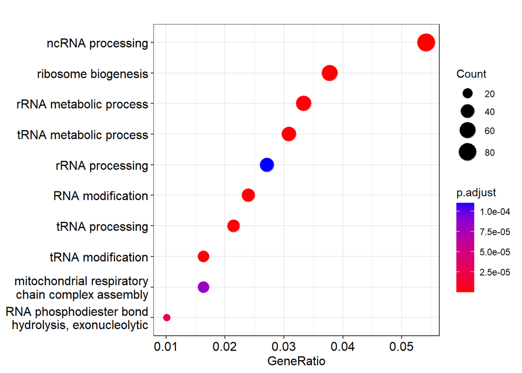

```r
### let's now look at the right-most high-density area
spot2 <- se.prtcod[which( se.prtcod$PC1 > 30 &
                          se.prtcod$PC1 < 70 &
                          se.prtcod$PC2 > -6 &
                          se.prtcod$PC2 <  6),]
gene2 <- gsub('\\..*', '', rownames(spot2))
GOE2 <- enrichGO(gene          = gene2,
                 keyType       = "ENSEMBL",
                 OrgDb         = org.Hs.eg.db,
                 ont           = "BP",
                 pAdjustMethod = "BH",
                 pvalueCutoff  = 0.01,
                 qvalueCutoff  = 0.05,
                 readable      = TRUE)
dotplot(GOE2)
```

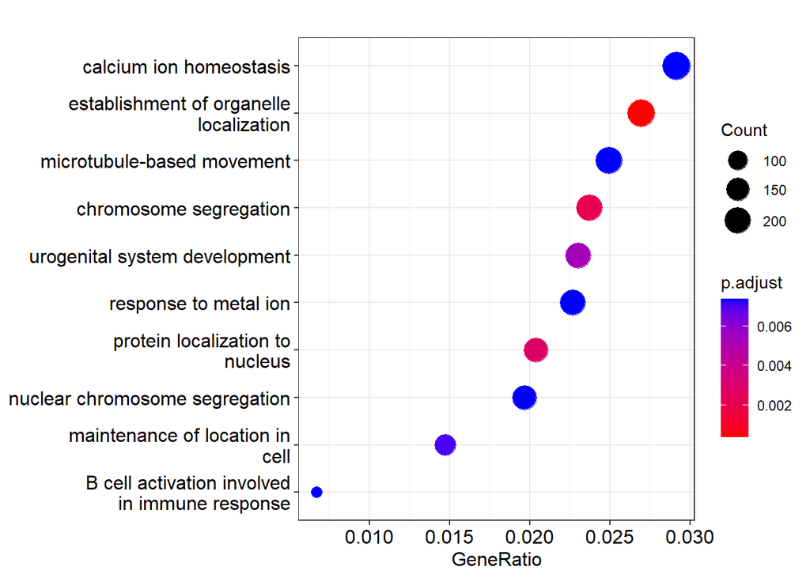

```r
### let's finally look at all the data points
gene3 <- gsub('\\..*', '', rownames(assay(se)))
GOE3 <- enrichGO(gene          = gene3,
                 keyType       = "ENSEMBL",
                 OrgDb         = org.Hs.eg.db,
                 ont           = "BP",
                 pAdjustMethod = "BH",
                 pvalueCutoff  = 0.01,
                 qvalueCutoff  = 0.05,
                 readable      = TRUE)
dotplot(GOE3)
```

```r
###quick side analysis for which RNAs are most heavily bound to YBX3
#ensg.ids <- rownames(assay(se))[assay(se)[,'ENCSR529FKI'] > 20]
#gene3 <- gsub('\\..*', '', ensg.ids)
#GOE3 <- enrichGO(gene          = gene3,
#                 keyType       = "ENSEMBL",
#                 OrgDb         = org.Hs.eg.db,
#                 ont           = "MF",
#                 pAdjustMethod = "BH",
#                 pvalueCutoff  = 0.01,
#                 qvalueCutoff  = 0.05,
#                 readable      = TRUE)
#dotplot(GOE3)
```

### Clustering Analysis - HEPG2 Cells

We repeat the clustering analysis performed on K562 cells. This time, we focus on HEPG2 cells.

Step 1: Load the SummarizedExperiment for HEPG2.

Step 2: Scale counts data by column (eCLIP experiment), remove RNAs relatively unbound by proteins.

```r
### scale assay(se) by column sums, multiply by 10e7 and round so that the values we work with are integers
prot.sum   <- colSums(assay(HEPG2.se2))
assay(HEPG2.se2) <- scale(assay(HEPG2.se2), center=FALSE, scale=prot.sum) * 10e7 %>%
              round(digits = 0)
### remove RNAs with low eCLIP data
rna.sum  <- rowSums(assay(HEPG2.se2))
genes    <- rownames(assay(HEPG2.se2))
genes.hi <- genes[which(rna.sum>100)]
### recreate SummarizedExperiment
se <- SummarizedExperiment(assays=list(counts=assay(HEPG2.se2)[genes.hi,]^0.25), colData = colData(HEPG2.se2), rowData=rowData(HEPG2.se2)[genes.hi,])
```

Step 3: Using data for the 103 available eCLIP experiments in HEPG2 cells, figure out how similar the 103 eCLIP proteins are in terms of their binding to mRNAs and lncRNAs.

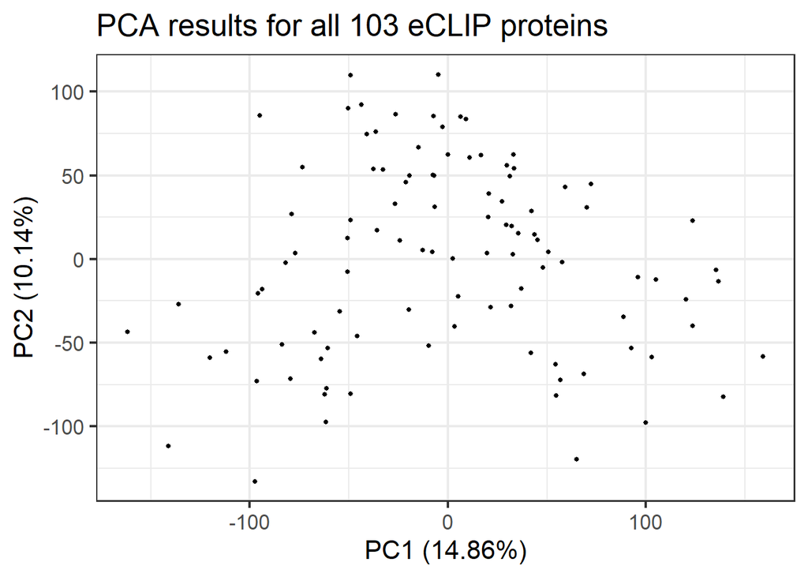

```r
### PCA on eCLIP proteins
prot.pca <- prcomp(t(assay(se)))
prot.pca.var <- prot.pca$sdev^2
prot.pca.var.prop <- prot.pca.var/sum(prot.pca.var) * 100
prot.PC1PC2 <- data.frame(prot.pca$x[,1:2])
prot.PC1PC2[rownames(colData(se)),"proteins"] <- colData(se)$Experiment.target
ggplot(prot.PC1PC2) + geom_point(aes(PC1, PC2), size = 1) +
  ggtitle('PCA results for all 103 eCLIP proteins') +
  xlab('PC1 (14.86%)') +
  ylab('PC2 (10.14%)')
```

Step 4: Color-code lncRNAs (teal) and mRNAs (coral) in the SummarizedExperiment. This will be helpful later.

```r
lncRNA.id <- rowData(se)$Gene_type=='lncRNA'
prtcod.id <- rowData(se)$Gene_type=='protein_coding'
genes   <- rownames(rowData(se))
lncRNAs <- genes[lncRNA.id]
prtcods <- genes[prtcod.id]
### color-code lncRNAs and mRNAs in the se
rowData(se)[lncRNA.id, "colors"] <- "#f34c28"
rowData(se)[prtcod.id, "colors"] <- "#2ca1d7"
```